# StormDataAnalysis

NithaDuff

7/11/2020

This project involves exploring the U.S. National Oceanic and Atmospheric Administration’s (NOAA) storm database. This database tracks characteristics of major storms and weather events in the United States, including when and where they occur, as well as estimates of any fatalities, injuries, and property damage.

```r
library(dplyr)
```

```r
library(stringr)
library(ggplot2)
storm_data <- read.csv("Storm_DA/repdata_data_StormData.csv.bz2",na.strings = c('',' ',NA,'?')) %>%  mutate_all(.funs=toupper)
storm_data$EVTYPE <-   str_replace(storm_data$EVTYPE,'S$','') %>% str_trim()
```

In the first analysis, we required FATALITIES and INJURIES hence we convert the 2 columns into usable forms i.e numeric. Similarly the second analysis in the economic impact which are CROP DAMAGE and PROPERTY DAMAGE accordingly.

```r
storm_data$INJURIES <- as.numeric(storm_data$INJURIES)
storm_data$FATALITIES <- as.numeric(storm_data$FATALITIES)
storm_data$CROPDMG <- as.numeric(storm_data$CROPDMG)
storm_data$PROPDMG <- as.numeric(storm_data$PROPDMG)
```

In order to analyze the economic impacts, we need the consider 2 variables such as PROPERTY DAMAGE and CROP DAMAGE. These two variables are split into 2 columns such as magnitude and exponent. Hence we need to process the variables in order to be available for calculation:

```r
storm_data$CROPDMGEXP <- storm_data$CROPDMGEXP %>% str_replace_all("K","3")  %>%
  str_replace_all("M","6") %>%
  str_replace_all("B","9")
storm_data$CROPDMGEXP <- as.numeric(storm_data$CROPDMGEXP)
storm_data$CROPDMGEXP <- 10^storm_data$CROPDMGEXP
storm_data$CROPDMG <- as.numeric(storm_data$CROPDMG)

storm_data$PROPDMGEXP <- storm_data$PROPDMGEXP %>% str_replace_all("H","10")  %>%
  str_replace_all("\\-","-1") %>%
  str_replace_all("\\+","1") %>%
  str_replace_all("K","3")  %>%
  str_replace_all("M","6") %>%
  str_replace_all("B","9")
storm_data$PROPDMGEXP <- as.numeric(storm_data$PROPDMGEXP)
storm_data$PROPDMGEXP <- 10^storm_data$PROPDMGEXP
storm_data$PROPDMG <- as.numeric(storm_data$PROPDMG)
```

The Total and exponential values are combined in orde to get the final value:

```r
storm_data$cropdmgtot <- storm_data$CROPDMG + storm_data$CROPDMGEXP
storm_data$propdmgtot <- storm_data$PROPDMG + storm_data$PROPDMGEXP
```

The total data in grouped according to event type(EVTYPE) in order to get the total of the event wise impact on the human health factor

```r
storm_data <- storm_data  %>%
  group_by(EVTYPE) %>%
  summarise(total_injury = sum(INJURIES,na.rm = T), total_fatality = sum(FATALITIES,na.rm = T),
            total_cropdmg = sum(cropdmgtot,na.rm = T), total_propdmg = sum(propdmgtot,na.rm = T))
head(storm_data)
```

```
## # A tibble: 6 x 5
##   EVTYPE               total_injury total_fatality total_cropdmg total_propdmg
##   <chr>                       <dbl>          <dbl>         <dbl>         <dbl>
## 1 ABNORMAL WARMTH                 0              0            0              0
## 2 ABNORMALLY DRY                  0              0            0              0
## 3 ABNORMALLY WET                  0              0            0              0
## 4 ACCUMULATED SNOWFALL            0              0            0              0
## 5 AGRICULTURAL FREEZE             0              0      3000029.             0
## 6 APACHE COUNTY                   0              0            0           1005
```

```r
storm_data$total_impact_health <- storm_data$total_injury + storm_data$total_fatality
```

Maximum impact of the event is:

```r
max_health_effect <- storm_data$total_impact_health == max(storm_data$total_impact_health)
storm_data[max_health_effect,"EVTYPE"] %>% print
```

```
## # A tibble: 1 x 1
##   EVTYPE
##   <chr>
## 1 TORNADO
```

The relative impact with respect to events has been depicted in the following plot. Since the total events are beyond what can be depicted in a single plot. From the entire data a few top scorers have been picked based on a significant lower limit. This does not depict that these are only the events that cause an impact, rather these are the top players among 800+ events and the health impacts caused by them.

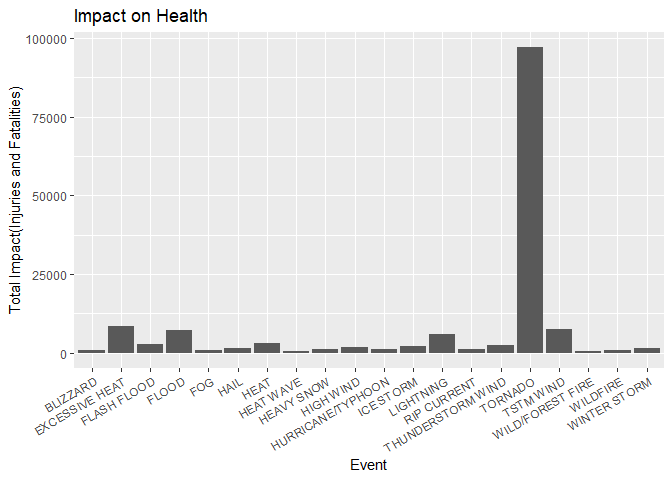

```r
significant_impact <- storm_data$total_impact_health >= 500.0
g <- ggplot(storm_data[significant_impact,], aes(x = EVTYPE, y = total_impact_health)) +
  geom_bar(stat = "identity") +
  labs(title = "Impact on Health", x = "Event", y = "Total Impact(Injuries and Fatalities)") +
  theme(axis.text.x = element_text(angle = 30, hjust=1))
print(g)
```

```r
storm_data$total_impact_eco <- storm_data$total_cropdmg + storm_data$total_propdmg
```

Maximum impact of economy is:

```r
max_eco_effect <- storm_data$total_impact_eco == max(storm_data$total_impact_eco)
storm_data[max_eco_effect,"EVTYPE"] %>% print
```

```
## # A tibble: 1 x 1
##   EVTYPE
##   <chr>
## 1 THUNDERSTORM WIND
```

The relative plot showing the main contributors to the economic impact along with a few top players have been shown.

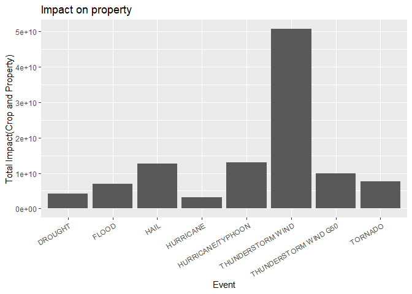

```r
significant_impact <- storm_data$total_impact_eco >= 0.3e+10
g <- ggplot(storm_data[significant_impact,], aes(x = EVTYPE, y = total_impact_eco)) +
  geom_bar(stat = "identity") +
  labs(title = "Impact on property", x = "Event", y = "Total Impact(Crop and Property)") +
  theme(axis.text.x = element_text(angle = 30, hjust=1))
print(g)
```